# zomato

```python
import pandas as pd
import numpy as np
import matplotlib.pyplot as plt
import seaborn as sns
%matplotlib inline
```

reading the data

```python
import matplotlib
```

```python
df = pd.read_csv('zomato.csv',encoding='latin-1')
```

```python
df.head()
```

|  | Restaurant ID | Restaurant Name | Country Code | City | Address | Locality | Locality Verbose | Longitude | Latitude | Cuisines | ... | Currency | Has Table booking | Has Online delivery | Is delivering now | Switch to order menu | Price range | Aggregate rating | Rating color | Rating text | Votes |
| --- | --- | --- | --- | --- | --- | --- | --- | --- | --- | --- | --- | --- | --- | --- | --- | --- | --- | --- | --- | --- | --- |
| 0 | 6317637 | Le Petit Souffle | 162 | Makati City | Third Floor, Century City Mall, Kalayaan Avenu... | Century City Mall, Poblacion, Makati City | Century City Mall, Poblacion, Makati City, Mak... | 121.027535 | 14.565443 | French, Japanese, Desserts | ... | Botswana Pula(P) | Yes | No | No | No | 3 | 4.8 | Dark Green | Excellent | 314 |
| 1 | 6304287 | Izakaya Kikufuji | 162 | Makati City | Little Tokyo, 2277 Chino Roces Avenue, Legaspi... | Little Tokyo, Legaspi Village, Makati City | Little Tokyo, Legaspi Village, Makati City, Ma... | 121.014101 | 14.553708 | Japanese | ... | Botswana Pula(P) | Yes | No | No | No | 3 | 4.5 | Dark Green | Excellent | 591 |
| 2 | 6300002 | Heat - Edsa Shangri-La | 162 | Mandaluyong City | Edsa Shangri-La, 1 Garden Way, Ortigas, Mandal... | Edsa Shangri-La, Ortigas, Mandaluyong City | Edsa Shangri-La, Ortigas, Mandaluyong City, Ma... | 121.056831 | 14.581404 | Seafood, Asian, Filipino, Indian | ... | Botswana Pula(P) | Yes | No | No | No | 4 | 4.4 | Green | Very Good | 270 |
| 3 | 6318506 | Ooma | 162 | Mandaluyong City | Third Floor, Mega Fashion Hall, SM Megamall, O... | SM Megamall, Ortigas, Mandaluyong City | SM Megamall, Ortigas, Mandaluyong City, Mandal... | 121.056475 | 14.585318 | Japanese, Sushi | ... | Botswana Pula(P) | No | No | No | No | 4 | 4.9 | Dark Green | Excellent | 365 |
| 4 | 6314302 | Sambo Kojin | 162 | Mandaluyong City | Third Floor, Mega Atrium, SM Megamall, Ortigas... | SM Megamall, Ortigas, Mandaluyong City | SM Megamall, Ortigas, Mandaluyong City, Mandal... | 121.057508 | 14.584450 | Japanese, Korean | ... | Botswana Pula(P) | Yes | No | No | No | 4 | 4.8 | Dark Green | Excellent | 229 |

5 rows × 21 columns

```python
df.columns
```

```
Index(['Restaurant ID', 'Restaurant Name', 'Country Code', 'City', 'Address',
       'Locality', 'Locality Verbose', 'Longitude', 'Latitude', 'Cuisines',
       'Average Cost for two', 'Currency', 'Has Table booking',
       'Has Online delivery', 'Is delivering now', 'Switch to order menu',
       'Price range', 'Aggregate rating', 'Rating color', 'Rating text',
       'Votes'],
      dtype='object')
```

some info about the data

```python
df.info()
```

```
<class 'pandas.core.frame.DataFrame'>
RangeIndex: 9551 entries, 0 to 9550
Data columns (total 21 columns):
 #   Column                Non-Null Count  Dtype
---  ------                --------------  -----
 0   Restaurant ID         9551 non-null   int64
 1   Restaurant Name       9551 non-null   object
 2   Country Code          9551 non-null   int64
 3   City                  9551 non-null   object
 4   Address               9551 non-null   object
 5   Locality              9551 non-null   object
 6   Locality Verbose      9551 non-null   object
 7   Longitude             9551 non-null   float64
 8   Latitude              9551 non-null   float64
 9   Cuisines              9542 non-null   object
 10  Average Cost for two  9551 non-null   int64
 11  Currency              9551 non-null   object
 12  Has Table booking     9551 non-null   object
 13  Has Online delivery   9551 non-null   object
 14  Is delivering now     9551 non-null   object
 15  Switch to order menu  9551 non-null   object
 16  Price range           9551 non-null   int64
 17  Aggregate rating      9551 non-null   float64
 18  Rating color          9551 non-null   object
 19  Rating text           9551 non-null   object
 20  Votes                 9551 non-null   int64
dtypes: float64(3), int64(5), object(13)
memory usage: 1.5+ MB
```

```python
df.describe().T
```

|  | count | mean | std | min | 25% | 50% | 75% | max |
| --- | --- | --- | --- | --- | --- | --- | --- | --- |
| Restaurant ID | 9551.0 | 9.051128e+06 | 8.791521e+06 | 53.000000 | 301962.500000 | 6.004089e+06 | 1.835229e+07 | 1.850065e+07 |
| Country Code | 9551.0 | 1.836562e+01 | 5.675055e+01 | 1.000000 | 1.000000 | 1.000000e+00 | 1.000000e+00 | 2.160000e+02 |
| Longitude | 9551.0 | 6.412657e+01 | 4.146706e+01 | -157.948486 | 77.081343 | 7.719196e+01 | 7.728201e+01 | 1.748321e+02 |
| Latitude | 9551.0 | 2.585438e+01 | 1.100794e+01 | -41.330428 | 28.478713 | 2.857047e+01 | 2.864276e+01 | 5.597698e+01 |
| Average Cost for two | 9551.0 | 1.199211e+03 | 1.612118e+04 | 0.000000 | 250.000000 | 4.000000e+02 | 7.000000e+02 | 8.000000e+05 |
| Price range | 9551.0 | 1.804837e+00 | 9.056088e-01 | 1.000000 | 1.000000 | 2.000000e+00 | 2.000000e+00 | 4.000000e+00 |
| Aggregate rating | 9551.0 | 2.666370e+00 | 1.516378e+00 | 0.000000 | 2.500000 | 3.200000e+00 | 3.700000e+00 | 4.900000e+00 |
| Votes | 9551.0 | 1.569097e+02 | 4.301691e+02 | 0.000000 | 5.000000 | 3.100000e+01 | 1.310000e+02 | 1.093400e+04 |

Todo:

1.Check for missing values

2.explore and try to understand numeric data

3.explore and try to understand categorical or continuous data

4.find relationships between features

```python
df.isnull().sum()
```

```
Restaurant ID           0
Restaurant Name         0
Country Code            0
City                    0
Address                 0
Locality                0
Locality Verbose        0
Longitude               0
Latitude                0
Cuisines                9
Average Cost for two    0
Currency                0
Has Table booking       0
Has Online delivery     0
Is delivering now       0
Switch to order menu    0
Price range             0
Aggregate rating        0
Rating color            0
Rating text             0
Votes                   0
dtype: int64
```

there are nulls in (Cuisines) (9 nulls)

```python
[f for f in df.columns if df[f].isnull().sum()>0]
```

```
['Cuisines']
```

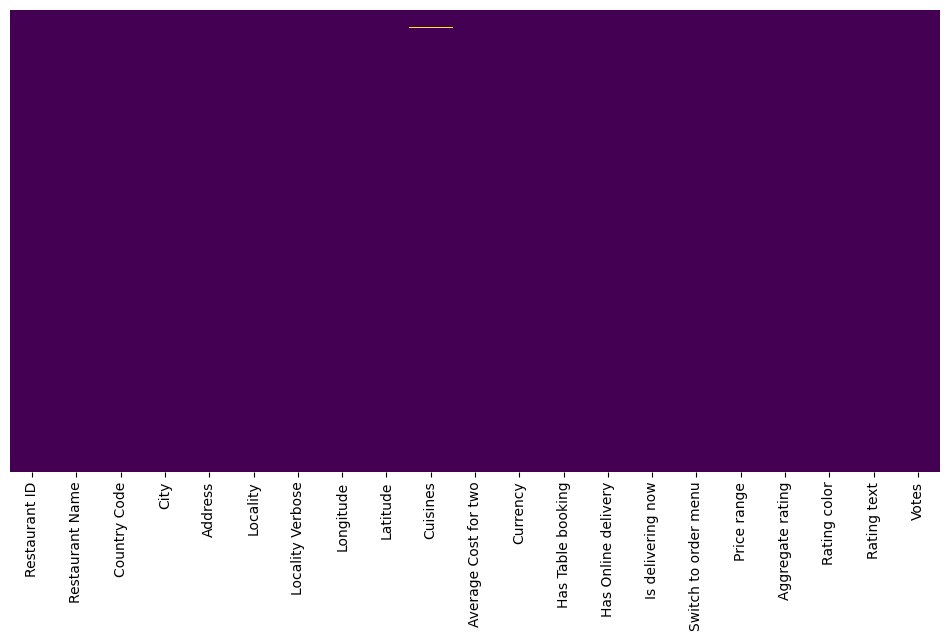

```python
matplotlib.rcParams['figure.figsize'] = (12,6)
sns.heatmap(df.isnull(),yticklabels=False,cbar=False,cmap='viridis')
plt.show()
```

```python
df_country = pd.read_excel('Country-Code.xlsx')
```

```python
df_country.head()
```

|  | Country Code | Country |
| --- | --- | --- |
| 0 | 1 | India |
| 1 | 14 | Australia |
| 2 | 30 | Brazil |
| 3 | 37 | Canada |
| 4 | 94 | Indonesia |

```python
df.head()
```

|  | Restaurant ID | Restaurant Name | Country Code | City | Address | Locality | Locality Verbose | Longitude | Latitude | Cuisines | ... | Currency | Has Table booking | Has Online delivery | Is delivering now | Switch to order menu | Price range | Aggregate rating | Rating color | Rating text | Votes |
| --- | --- | --- | --- | --- | --- | --- | --- | --- | --- | --- | --- | --- | --- | --- | --- | --- | --- | --- | --- | --- | --- |
| 0 | 6317637 | Le Petit Souffle | 162 | Makati City | Third Floor, Century City Mall, Kalayaan Avenu... | Century City Mall, Poblacion, Makati City | Century City Mall, Poblacion, Makati City, Mak... | 121.027535 | 14.565443 | French, Japanese, Desserts | ... | Botswana Pula(P) | Yes | No | No | No | 3 | 4.8 | Dark Green | Excellent | 314 |
| 1 | 6304287 | Izakaya Kikufuji | 162 | Makati City | Little Tokyo, 2277 Chino Roces Avenue, Legaspi... | Little Tokyo, Legaspi Village, Makati City | Little Tokyo, Legaspi Village, Makati City, Ma... | 121.014101 | 14.553708 | Japanese | ... | Botswana Pula(P) | Yes | No | No | No | 3 | 4.5 | Dark Green | Excellent | 591 |
| 2 | 6300002 | Heat - Edsa Shangri-La | 162 | Mandaluyong City | Edsa Shangri-La, 1 Garden Way, Ortigas, Mandal... | Edsa Shangri-La, Ortigas, Mandaluyong City | Edsa Shangri-La, Ortigas, Mandaluyong City, Ma... | 121.056831 | 14.581404 | Seafood, Asian, Filipino, Indian | ... | Botswana Pula(P) | Yes | No | No | No | 4 | 4.4 | Green | Very Good | 270 |
| 3 | 6318506 | Ooma | 162 | Mandaluyong City | Third Floor, Mega Fashion Hall, SM Megamall, O... | SM Megamall, Ortigas, Mandaluyong City | SM Megamall, Ortigas, Mandaluyong City, Mandal... | 121.056475 | 14.585318 | Japanese, Sushi | ... | Botswana Pula(P) | No | No | No | No | 4 | 4.9 | Dark Green | Excellent | 365 |
| 4 | 6314302 | Sambo Kojin | 162 | Mandaluyong City | Third Floor, Mega Atrium, SM Megamall, Ortigas... | SM Megamall, Ortigas, Mandaluyong City | SM Megamall, Ortigas, Mandaluyong City, Mandal... | 121.057508 | 14.584450 | Japanese, Korean | ... | Botswana Pula(P) | Yes | No | No | No | 4 | 4.8 | Dark Green | Excellent | 229 |

5 rows × 21 columns

```python
final_df = pd.merge(df,df_country,on='Country Code',how='left')
```

merge these 2 files together

```python
final_df.head(3)
```

|  | Restaurant ID | Restaurant Name | Country Code | City | Address | Locality | Locality Verbose | Longitude | Latitude | Cuisines | ... | Has Table booking | Has Online delivery | Is delivering now | Switch to order menu | Price range | Aggregate rating | Rating color | Rating text | Votes | Country |
| --- | --- | --- | --- | --- | --- | --- | --- | --- | --- | --- | --- | --- | --- | --- | --- | --- | --- | --- | --- | --- | --- |
| 0 | 6317637 | Le Petit Souffle | 162 | Makati City | Third Floor, Century City Mall, Kalayaan Avenu... | Century City Mall, Poblacion, Makati City | Century City Mall, Poblacion, Makati City, Mak... | 121.027535 | 14.565443 | French, Japanese, Desserts | ... | Yes | No | No | No | 3 | 4.8 | Dark Green | Excellent | 314 | Phillipines |
| 1 | 6304287 | Izakaya Kikufuji | 162 | Makati City | Little Tokyo, 2277 Chino Roces Avenue, Legaspi... | Little Tokyo, Legaspi Village, Makati City | Little Tokyo, Legaspi Village, Makati City, Ma... | 121.014101 | 14.553708 | Japanese | ... | Yes | No | No | No | 3 | 4.5 | Dark Green | Excellent | 591 | Phillipines |
| 2 | 6300002 | Heat - Edsa Shangri-La | 162 | Mandaluyong City | Edsa Shangri-La, 1 Garden Way, Ortigas, Mandal... | Edsa Shangri-La, Ortigas, Mandaluyong City | Edsa Shangri-La, Ortigas, Mandaluyong City, Ma... | 121.056831 | 14.581404 | Seafood, Asian, Filipino, Indian | ... | Yes | No | No | No | 4 | 4.4 | Green | Very Good | 270 | Phillipines |

3 rows × 22 columns

```python
final_df.dtypes
```

```
Restaurant ID             int64
Restaurant Name          object
Country Code              int64
City                     object
Address                  object
Locality                 object
Locality Verbose         object
Longitude               float64
Latitude                float64
Cuisines                 object
Average Cost for two      int64
Currency                 object
Has Table booking        object
Has Online delivery      object
Is delivering now        object
Switch to order menu     object
Price range               int64
Aggregate rating        float64
Rating color             object
Rating text              object
Votes                     int64
Country                  object
dtype: object
```

number of columns for each country :

```python
co_no = final_df.Country.value_counts()
```

lets visualize it

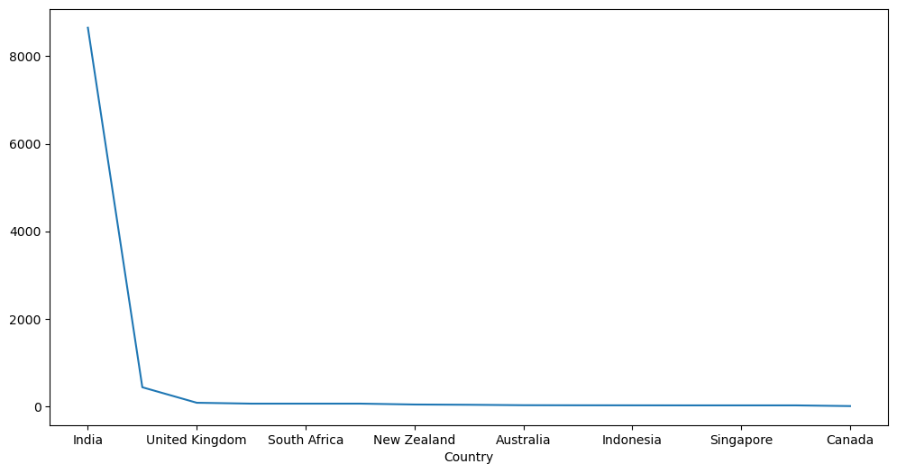

```python
co_no.plot()
plt.show()
```

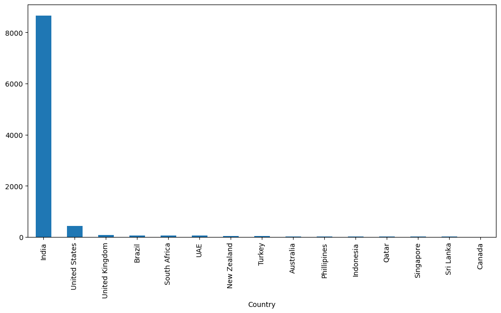

```python
co_no.plot(kind='bar')
plt.show()
```

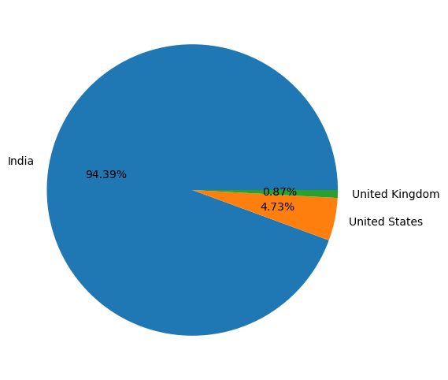

```python
country_names = co_no.index.tolist()
country_values = co_no.values.tolist()
plt.pie(country_values[:3],labels=country_names[:3],autopct='%.2f%%')
plt.show()
```

india is dominating , then USA and then UK

```python
final_df.dtypes
```

```
Restaurant ID             int64
Restaurant Name          object
Country Code              int64
City                     object
Address                  object
Locality                 object
Locality Verbose         object
Longitude               float64
Latitude                float64
Cuisines                 object
Average Cost for two      int64
Currency                 object
Has Table booking        object
Has Online delivery      object
Is delivering now        object
Switch to order menu     object
Price range               int64
Aggregate rating        float64
Rating color             object
Rating text              object
Votes                     int64
Country                  object
dtype: object
```

```python
list  = (final_df.dtypes.values !='object')
final_df.dtypes[list]
```

```
Restaurant ID             int64
Country Code              int64
Longitude               float64
Latitude                float64
Average Cost for two      int64
Price range               int64
Aggregate rating        float64
Votes                     int64
dtype: object
```

```python
rating_df = final_df.groupby(['Aggregate rating','Rating color','Rating text'])['Votes'].count().reset_index(name='Votes Count')

rating_df
```

|  | Aggregate rating | Rating color | Rating text | Votes Count |
| --- | --- | --- | --- | --- |
| 0 | 0.0 | White | Not rated | 2148 |
| 1 | 1.8 | Red | Poor | 1 |
| 2 | 1.9 | Red | Poor | 2 |
| 3 | 2.0 | Red | Poor | 7 |
| 4 | 2.1 | Red | Poor | 15 |
| 5 | 2.2 | Red | Poor | 27 |
| 6 | 2.3 | Red | Poor | 47 |
| 7 | 2.4 | Red | Poor | 87 |
| 8 | 2.5 | Orange | Average | 110 |
| 9 | 2.6 | Orange | Average | 191 |
| 10 | 2.7 | Orange | Average | 250 |
| 11 | 2.8 | Orange | Average | 315 |
| 12 | 2.9 | Orange | Average | 381 |
| 13 | 3.0 | Orange | Average | 468 |
| 14 | 3.1 | Orange | Average | 519 |
| 15 | 3.2 | Orange | Average | 522 |
| 16 | 3.3 | Orange | Average | 483 |
| 17 | 3.4 | Orange | Average | 498 |
| 18 | 3.5 | Yellow | Good | 480 |
| 19 | 3.6 | Yellow | Good | 458 |
| 20 | 3.7 | Yellow | Good | 427 |
| 21 | 3.8 | Yellow | Good | 400 |
| 22 | 3.9 | Yellow | Good | 335 |
| 23 | 4.0 | Green | Very Good | 266 |
| 24 | 4.1 | Green | Very Good | 274 |
| 25 | 4.2 | Green | Very Good | 221 |
| 26 | 4.3 | Green | Very Good | 174 |
| 27 | 4.4 | Green | Very Good | 144 |
| 28 | 4.5 | Dark Green | Excellent | 95 |
| 29 | 4.6 | Dark Green | Excellent | 78 |
| 30 | 4.7 | Dark Green | Excellent | 42 |
| 31 | 4.8 | Dark Green | Excellent | 25 |
| 32 | 4.9 | Dark Green | Excellent | 61 |

```python
rating_df.tail()
```

|  | Aggregate rating | Rating color | Rating text | Votes Count |
| --- | --- | --- | --- | --- |
| 28 | 4.5 | Dark Green | Excellent | 95 |
| 29 | 4.6 | Dark Green | Excellent | 78 |
| 30 | 4.7 | Dark Green | Excellent | 42 |
| 31 | 4.8 | Dark Green | Excellent | 25 |
| 32 | 4.9 | Dark Green | Excellent | 61 |

an observation

: 0.0 is white , [>0.0:2.4] is poor and red [2.5:3.4] is orange and avg , [3.5:3.9] is Yellow and good

, [4:4.4] is Green and Very good , [4.5:4.9] is Dark Green and Excellent

lets see visualize the percentages of rating to colors

```python
rating_df2 = rating_df.groupby(['Rating text'])['Votes Count'].sum()
rating_df2.sort_values(inplace=True)
rating_df2
```

```
Rating text
Poor          186
Excellent     301
Very Good    1079
Good         2100
Not rated    2148
Average      3737
Name: Votes Count, dtype: int64
```

pie graph for each rating type and number of votes

this tells me percentages of ratings

```python
rating_colors = rating_df.groupby(['Rating color'])['Votes Count'].sum()
rating_colors.sort_values(inplace=True)
rating_colors.index.tolist()
colors = ['#FF0000',     # Red
          '#006400',     # Dark Green
          '#008000',     # Green
          '#FFFF00',     # Yellow
          '#DDDDDD',     # White
          '#FFA500']     # Orange
```

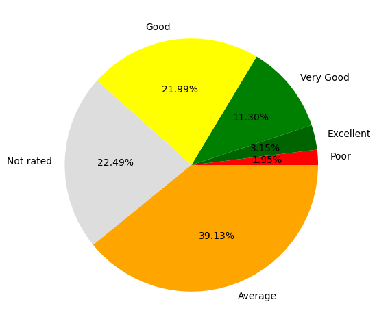

```python
rating_types = rating_df2.index.tolist()
rating_count = rating_df2.values.tolist()
plt.pie(rating_count,labels=rating_types,autopct='%.2f%%',colors=colors)
plt.show()
```

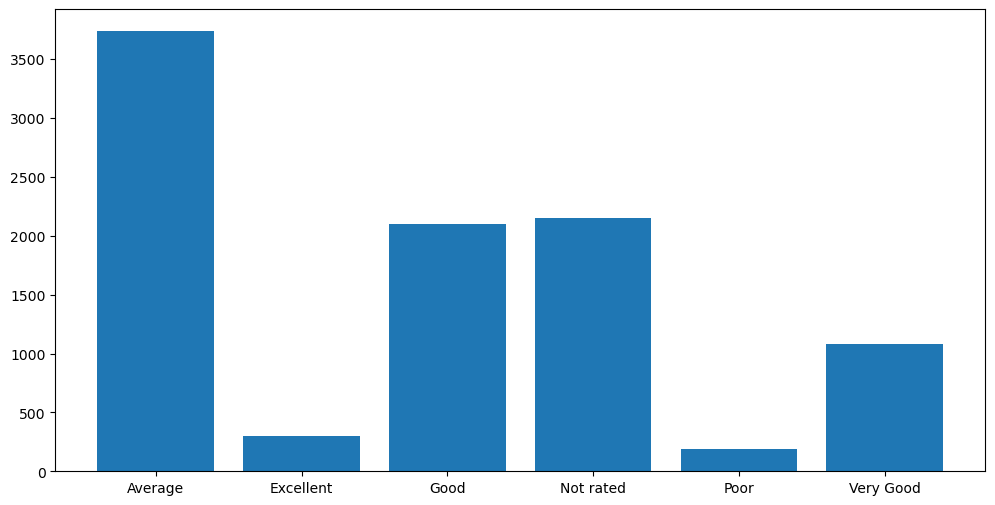

```python
plt.bar(rating_types,rating_count)
plt.show()
```

so here : most ratings are average [2.5:3.4]

```python
rating_df.head()
```

|  | Aggregate rating | Rating color | Rating text | Votes Count |
| --- | --- | --- | --- | --- |
| 0 | 0.0 | White | Not rated | 2148 |
| 1 | 1.8 | Red | Poor | 1 |
| 2 | 1.9 | Red | Poor | 2 |
| 3 | 2.0 | Red | Poor | 7 |
| 4 | 2.1 | Red | Poor | 15 |

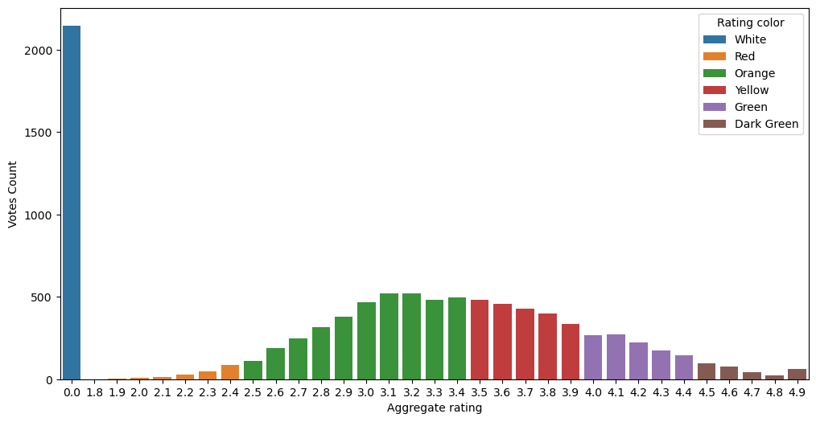

```python
sns.barplot(x="Aggregate rating",y="Votes Count",hue="Rating color",data=rating_df)
plt.show()
```

ratings from 0.0 to 4.9 vs votes count and it's close to normal distribution

some info about the votes

```python
votes = rating_df[['Aggregate rating','Votes Count']].set_index('Aggregate rating')
votes.describe()
```

|  | Votes Count |
| --- | --- |
| count | 33.000000 |
| mean | 289.424242 |
| std | 379.952713 |
| min | 1.000000 |
| 25% | 61.000000 |
| 50% | 221.000000 |
| 75% | 427.000000 |
| max | 2148.000000 |

lets find countries that have 0 rating

```python
rating_df
```

|  | Aggregate rating | Rating color | Rating text | Votes Count |
| --- | --- | --- | --- | --- |
| 0 | 0.0 | White | Not rated | 2148 |
| 1 | 1.8 | Red | Poor | 1 |
| 2 | 1.9 | Red | Poor | 2 |
| 3 | 2.0 | Red | Poor | 7 |
| 4 | 2.1 | Red | Poor | 15 |
| 5 | 2.2 | Red | Poor | 27 |
| 6 | 2.3 | Red | Poor | 47 |
| 7 | 2.4 | Red | Poor | 87 |
| 8 | 2.5 | Orange | Average | 110 |
| 9 | 2.6 | Orange | Average | 191 |
| 10 | 2.7 | Orange | Average | 250 |
| 11 | 2.8 | Orange | Average | 315 |
| 12 | 2.9 | Orange | Average | 381 |
| 13 | 3.0 | Orange | Average | 468 |
| 14 | 3.1 | Orange | Average | 519 |
| 15 | 3.2 | Orange | Average | 522 |
| 16 | 3.3 | Orange | Average | 483 |
| 17 | 3.4 | Orange | Average | 498 |
| 18 | 3.5 | Yellow | Good | 480 |
| 19 | 3.6 | Yellow | Good | 458 |
| 20 | 3.7 | Yellow | Good | 427 |
| 21 | 3.8 | Yellow | Good | 400 |
| 22 | 3.9 | Yellow | Good | 335 |
| 23 | 4.0 | Green | Very Good | 266 |
| 24 | 4.1 | Green | Very Good | 274 |
| 25 | 4.2 | Green | Very Good | 221 |
| 26 | 4.3 | Green | Very Good | 174 |
| 27 | 4.4 | Green | Very Good | 144 |
| 28 | 4.5 | Dark Green | Excellent | 95 |
| 29 | 4.6 | Dark Green | Excellent | 78 |
| 30 | 4.7 | Dark Green | Excellent | 42 |
| 31 | 4.8 | Dark Green | Excellent | 25 |
| 32 | 4.9 | Dark Green | Excellent | 61 |

```python
rating_df[rating_df['Aggregate rating'].values == 0]
```

|  | Aggregate rating | Rating color | Rating text | Votes Count |
| --- | --- | --- | --- | --- |
| 0 | 0.0 | White | Not rated | 2148 |

```python
country_rating = final_df[['Country','Aggregate rating']]
```

```python
country_rating = country_rating[country_rating['Aggregate rating']==0]
```

```python
country_rating
```

|  | Country | Aggregate rating |
| --- | --- | --- |
| 30 | Brazil | 0.0 |
| 58 | Brazil | 0.0 |
| 69 | Brazil | 0.0 |
| 77 | Brazil | 0.0 |
| 78 | Brazil | 0.0 |
| ... | ... | ... |
| 9109 | India | 0.0 |
| 9110 | India | 0.0 |
| 9111 | India | 0.0 |
| 9112 | India | 0.0 |
| 9351 | United Kingdom | 0.0 |

2148 rows × 2 columns

```python
country_rating =country_rating.groupby('Country')['Aggregate rating'].count()
```

```python
country_rating
```

```
Country
Brazil               5
India             2139
United Kingdom       1
United States        3
Name: Aggregate rating, dtype: int64
```

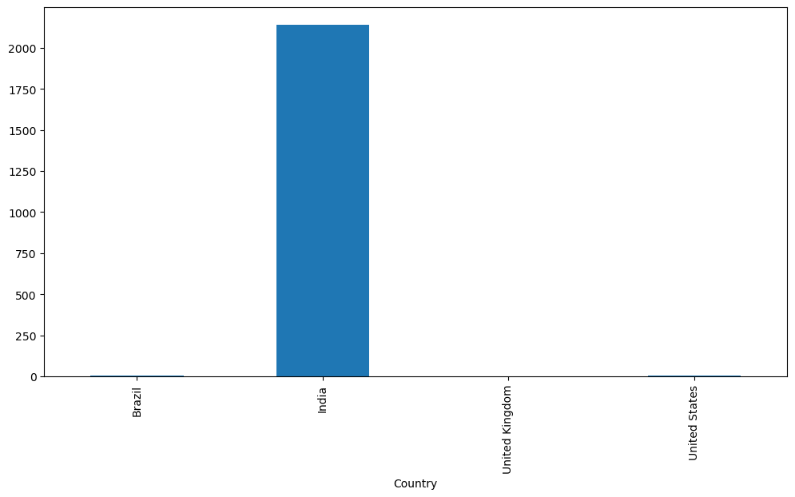

```python
country_rating.plot(kind='bar')
plt.show()
```

obs : india has the most 0.0 ratings

lets find which curruncy is used with each country

```python
counrty_currency = final_df.groupby(['Country','Currency']).size()
counrty_currency
```

```
Country         Currency
Australia       Dollar($)                   24
Brazil          Brazilian Real(R$)          60
Canada          Dollar($)                    4
India           Indian Rupees(Rs.)        8652
Indonesia       Indonesian Rupiah(IDR)      21
New Zealand     NewZealand($)               40
Phillipines     Botswana Pula(P)            22
Qatar           Qatari Rial(QR)             20
Singapore       Dollar($)                   20
South Africa    Rand(R)                     60
Sri Lanka       Sri Lankan Rupee(LKR)       20
Turkey          Turkish Lira(TL)            34
UAE             Emirati Diram(AED)          60
United Kingdom  Pounds(£)                  80
United States   Dollar($)                  434
dtype: int64
```

lets find which curruncy and it's countries

number of countries that uses each currency

```python
currency_counrty = final_df.groupby(['Currency','Country']).size()
currency_counrty = currency_counrty.groupby('Currency').count().reset_index().rename(columns={0:'number of countries'})
currency_counrty
```

|  | Currency | number of countries |
| --- | --- | --- |
| 0 | Botswana Pula(P) | 1 |
| 1 | Brazilian Real(R$) | 1 |
| 2 | Dollar($) | 4 |
| 3 | Emirati Diram(AED) | 1 |
| 4 | Indian Rupees(Rs.) | 1 |
| 5 | Indonesian Rupiah(IDR) | 1 |
| 6 | NewZealand($) | 1 |
| 7 | Pounds(£) | 1 |
| 8 | Qatari Rial(QR) | 1 |
| 9 | Rand(R) | 1 |
| 10 | Sri Lankan Rupee(LKR) | 1 |
| 11 | Turkish Lira(TL) | 1 |

lets visualize this

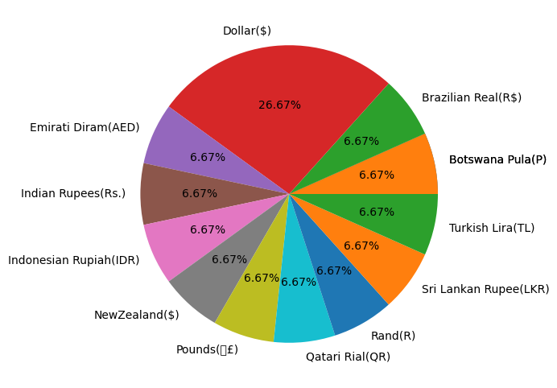

```python
currency = currency_counrty['Currency'].tolist()
country_count = currency_counrty['number of countries'].tolist()
plt.pie(country_count,labels=currency,autopct='%.2f%%')
plt.show()
```

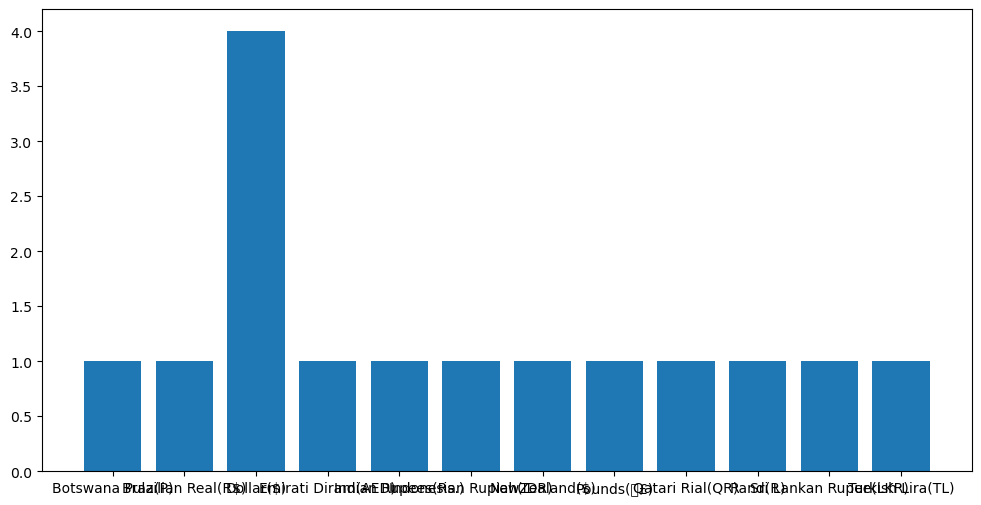

```python
plt.bar(currency,country_count)
plt.show()
```

Countries with online delivieis:

```python
countries_with_online_del = final_df[final_df['Has Online delivery'] == 'Yes'][['Country']].value_counts()
countries_with_online_del
```

```
Country
India      2423
UAE          28
Name: count, dtype: int64
```

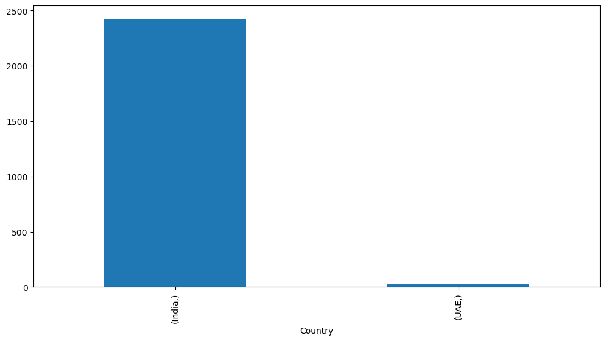

```python
countries_with_online_del.plot(kind='bar')
plt.show()
```

obs : online delivery is available in india and UAE

lets get cities in pie chart

```python
cities = final_df.City.value_counts()
cities.sort_values(ascending=False,inplace=True)
```

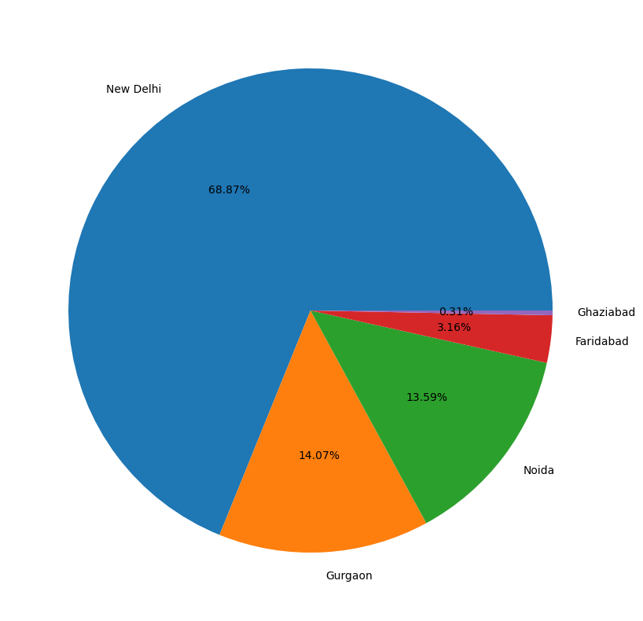

```python
cities_names = cities.index.tolist()
cities_values = cities.values.tolist()
matplotlib.rcParams['figure.figsize'] = (20,10)
plt.pie(cities_values[:5],labels=cities_names[:5],autopct='%.2f%%')
plt.show()
```

obs : New Delhi is the dominant then Gurgaun